# EU climate- and energy policies

Mark Roelfsema

08/04/2020

# Transport sector

Greenhouse gas emissions per mode

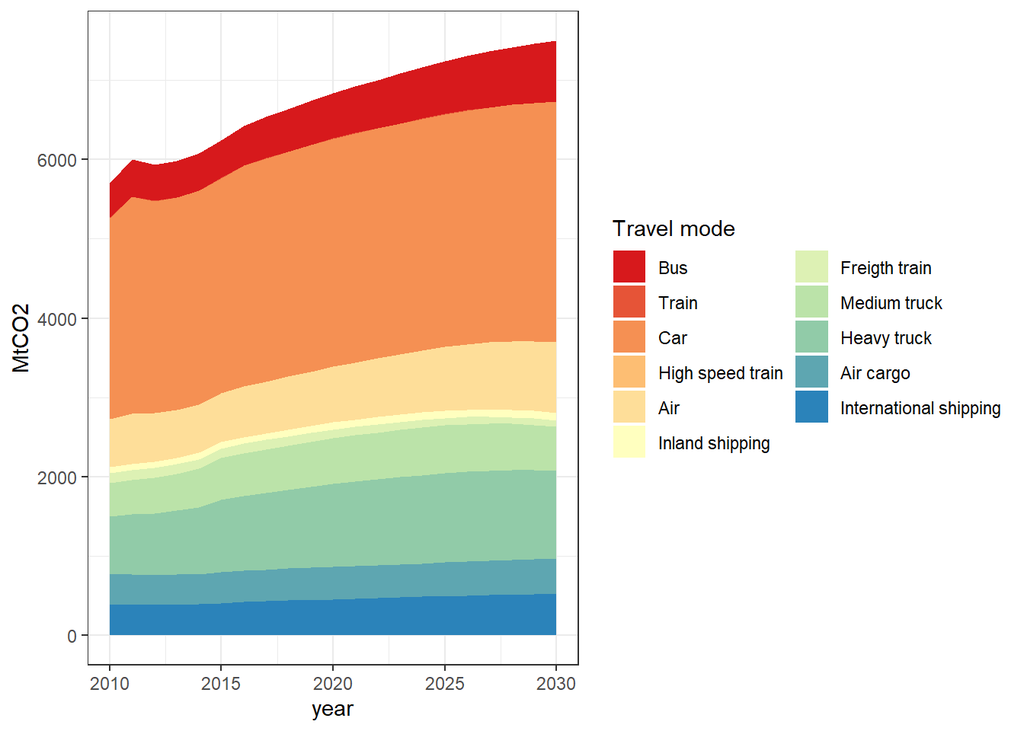

Policies modelled in TIMER * CO2 performance standards for **cars**, including electric share * Renewable target for **cars** (biofuels, electric cars) * CO2 performance standards for heavy trucks

Transpor modes not included * Policies for medium-trucks * Policicies for aviation (part of ETS), shipping (IMO standards) * Policies that impact train (train, high-speed train, freight train)

Transport policies not included * Fuel quality standard * CO2 performance standards, will be implemetned after 2022 review

## Reducing CO2 emissions from vehicles

1. Light-duty vehicle
- Cars
- Vans
3. Heavy-duty vehicles

## CO2 performance standards for cars

**Policy:** CO2 performance standards for cars

**Assumptions:** * CO2 intensity fuels is based on the assumption that there is a fixed ratio between gasoline and diesel (gasoline=43%), and this intensity also applies to other fuels. ** CO2 intensity gasoline is 2.4 gCO2/l, and CO2-intensity diesel is 2.7 gCO2/l * Energy intensity fuel is 34.841 MJ/l * load cars is 1.6 persons

**Methods:** * Energy use cars in TIMER is described in terms of MJ/pkm. CO2 intensity cars is calculated by translating this to CO2/km. * CO2 performance standards are implemented in TIMER by increasing the energy tax on oil and gas to a level that results in achieving the co2 performance standards for new cars.

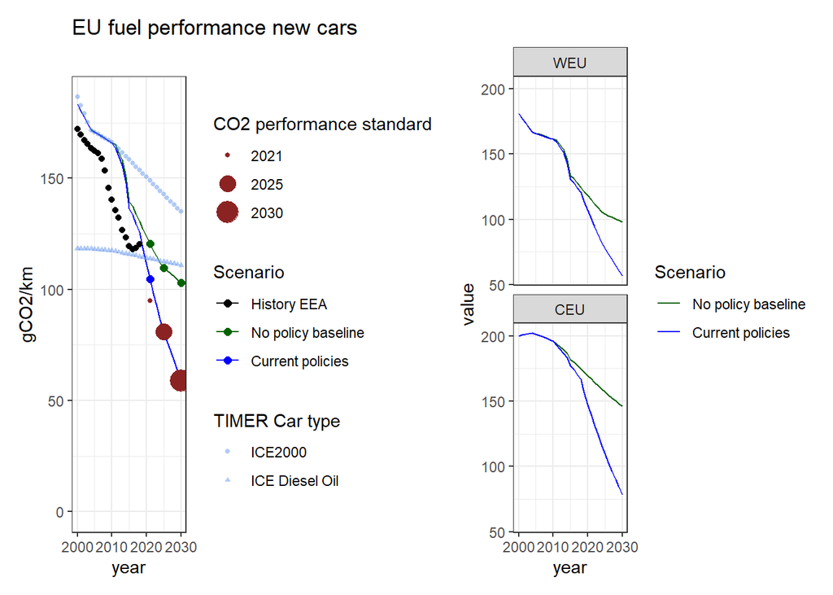

| year | value |
| --- | --- |
| 2021 | 95 |
| 2025 | 81 |
| 2030 | 59 |

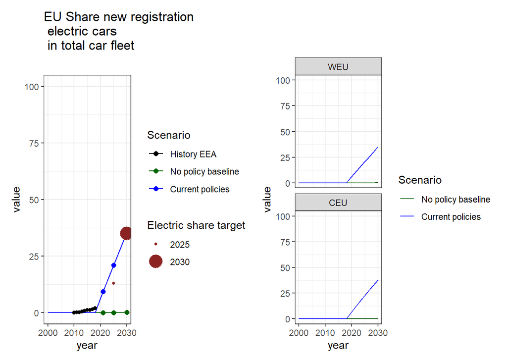

## Renewable energy in transport

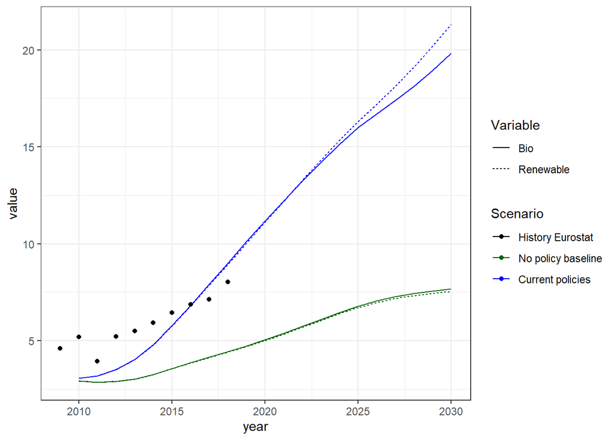

### Future improvements for modelling co2 car standards

- Include vans (other light-duty vehicles) –> but to which TIMER travel category do they belong, cars or medium trucks?
- Improve co2 performance standards ** Make load car dependent on TIMER data ** Currently only of gasoline and diesel are used to calcualted co2-intensity fuels, and gasoline is assumed to be 43% and diesel 57%. Add other fuels such as gas and biofuels, and make weight dependent on TIMER share in fleet
- EU CO2 standard allows for EV credits, add this to the TIMER indicator

### Future improvements for modelling electric share

- EU electric share target also includes plugins. Change TIMER indicator to include plugins.

## CO2 performance standards for heavy-trucks

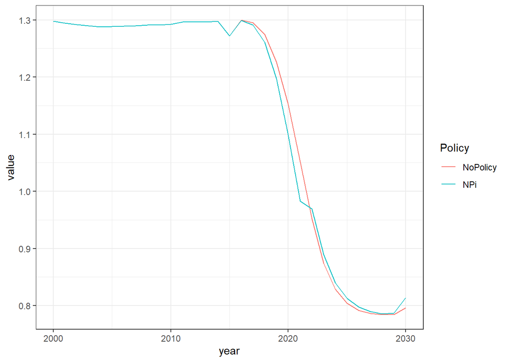

### Future improvements modeling heavy-trucks standard

- Where do medium trucks fit? And how do they compare to light-duty vehicles?
- Add busses (after 2022)